# Machine Learning & Statistical Data Mining with R

## Software Dependencies:

The code is compatible with: R - Version 3.3.2 R Studio - Version 0.99.903

## Library Dependencies:

The user needs to install the following packages (if not already present):'knitr', 'rmarkdown','plyr'

## Loading the Dependent Libraries:

```r
LoadLibraries= function (){
  library (ISLR)
  library (tree)
  library (gbm)
  library (MASS)
  library(rmarkdown)
  library(class)
  library (randomForest)
  library(gbm)
print (" The libraries have been loaded .")
}
LoadLibraries()
```

```
## [1] " The libraries have been loaded ."
```

## Terms

MSE: it stands for Minimum Squared Error

CV: it means Cross Validation

## Week 5 - Classification: Logistic regression, k-Nearest Neighbour

Exercise 10:

Question a) Produce some numerical and graphical summaries of the Weekly data

```r
#reload the original dataset to start from a clean position
data("Weekly")
#remove Weekly from the search() path of R objects
detach(Weekly)
#The database is searched by R when evaluating a variable,
#so objects in the database can be accessed by simply giving their names.
attach(Weekly)
```

Display of the ’Weekly’schema information.

```r
#View the data in a grid
fix(Weekly)

#Get the names of the variables
names(Weekly)
```

```
## [1] "Year"      "Lag1"      "Lag2"      "Lag3"      "Lag4"      "Lag5"
## [7] "Volume"    "Today"     "Direction"
```

```r
#Get schema definition
?Weekly
#List the number of rows and columns of the weekly dataset
dim(Weekly)
```

```
## [1] 1089    9
```

a) Today and Lags Analysis:

The median of Today,Lag1,Lag2,Lag3,Lag4 and Lag5 is respectively 0.2410,0.2410, 0.2410,0.2410,0.2380 and 0.2340.

50% of the data lies between the 1st (Q1) and the 3rd quartil (q3).

The Min and Max, correspond to the 25% of the data lying before Q1 and 25% after Q3 respectively.

b) Volume Analysis:

In terms of the Volume variable, the Q1 (0.33202) and Q3 (2.05373) are relatively close to the median (1.00268).

There seems to be a strong skew towards the right of the distribution tail, as the Max is away from the Q3 at 9.32.

```r
##The summary() function produces the interquartile range.
summary(Weekly)
```

```
##       Year           Lag1               Lag2               Lag3
##  Min.   :1990   Min.   :-18.1950   Min.   :-18.1950   Min.   :-18.1950
##  1st Qu.:1995   1st Qu.: -1.1540   1st Qu.: -1.1540   1st Qu.: -1.1580
##  Median :2000   Median :  0.2410   Median :  0.2410   Median :  0.2410
##  Mean   :2000   Mean   :  0.1506   Mean   :  0.1511   Mean   :  0.1472
##  3rd Qu.:2005   3rd Qu.:  1.4050   3rd Qu.:  1.4090   3rd Qu.:  1.4090
##  Max.   :2010   Max.   : 12.0260   Max.   : 12.0260   Max.   : 12.0260
##       Lag4               Lag5              Volume
##  Min.   :-18.1950   Min.   :-18.1950   Min.   :0.08747
##  1st Qu.: -1.1580   1st Qu.: -1.1660   1st Qu.:0.33202
##  Median :  0.2380   Median :  0.2340   Median :1.00268
##  Mean   :  0.1458   Mean   :  0.1399   Mean   :1.57462
##  3rd Qu.:  1.4090   3rd Qu.:  1.4050   3rd Qu.:2.05373
##  Max.   : 12.0260   Max.   : 12.0260   Max.   :9.32821
##      Today          Direction
##  Min.   :-18.1950   Down:484
##  1st Qu.: -1.1540   Up  :605
##  Median :  0.2410
##  Mean   :  0.1499
##  3rd Qu.:  1.4050
##  Max.   : 12.0260
```

The Correlation is a statistical measure that indicates the extent to which two or more variables fluctuate together.

Except from a high degree of correlation between the Year Vs Volume (0.84194), all the other pairwise correlations are very close to zero. This means it is probable that the change of the Year impacts the Volume, and reverse. But there is no causation, as there may be unknown factors that influence both variables similarly.

All the other pairwise correlations are very close to zero.This means there seems to be no influence of the prices on the Lag period on the price today or the volume.

```r
#Produce all the parwise correlation among the predictors in a dataset
cor(Weekly[,-9])
```

```
##               Year         Lag1        Lag2        Lag3         Lag4
## Year    1.00000000 -0.032289274 -0.03339001 -0.03000649 -0.031127923
## Lag1   -0.03228927  1.000000000 -0.07485305  0.05863568 -0.071273876
## Lag2   -0.03339001 -0.074853051  1.00000000 -0.07572091  0.058381535
## Lag3   -0.03000649  0.058635682 -0.07572091  1.00000000 -0.075395865
## Lag4   -0.03112792 -0.071273876  0.05838153 -0.07539587  1.000000000
## Lag5   -0.03051910 -0.008183096 -0.07249948  0.06065717 -0.075675027
## Volume  0.84194162 -0.064951313 -0.08551314 -0.06928771 -0.061074617
## Today  -0.03245989 -0.075031842  0.05916672 -0.07124364 -0.007825873
##                Lag5      Volume        Today
## Year   -0.030519101  0.84194162 -0.032459894
## Lag1   -0.008183096 -0.06495131 -0.075031842
## Lag2   -0.072499482 -0.08551314  0.059166717
## Lag3    0.060657175 -0.06928771 -0.071243639
## Lag4   -0.075675027 -0.06107462 -0.007825873
## Lag5    1.000000000 -0.05851741  0.011012698
## Volume -0.058517414  1.00000000 -0.033077783
## Today   0.011012698 -0.03307778  1.000000000
```

The plot displays the same behaviour. No conclusion can be drawn from the analysis of the plots (as the data is clustered shows as a band with large width) for all plots, bar the Volume Vs Year that seems to show some correlation.

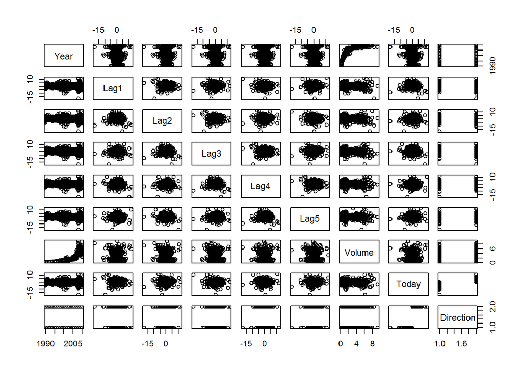

```r
plot(Weekly)
```

Question b) Use the full dataset to produce a Logistic Regression with Direction as the response and the five lag variables plus volume as predictors. Use the summary function to print the results. Do you see any predictor appearing as statistically significant? If so which ones

It is assumed that the alpha critical value is set at 5%.

From the table below we can deduce the following:

First, the intercept has a pValue of 0.0019 is which is less than the alpha critical value: 0.05. Therefore, it seems to be statistically significant. However, intercept in this case is of no real interest to the model. So, we can ignore it from the analysis.

Second, Lag2 has a pValue = 0.0296 which is less than 0.05. Therefore, we reject the hypothesis H0 that the coefficient beta for Lag2 = 0. We can deduce that the Lag2 beta is statistically significant. In other words, the predictor should have a significant impact on the predicted variable.

All the other variables have a pValue greater than 0.05, therefore none of these predicators seems to be statistically significant. They can be ignored.

The beta coefficient of Lag2 is 0.05844. It is slightly positive. It means that Lag2 and Direction should move in the same direction. This means if the market had a positive return two days ago, it is likely to go up today.

The standard error (0.02686) represents approximately 50% of the beta coefficient value (0.02686/0.05844). This shows a relatively high variance. Therefore, we need to be cautious about the conclusion relating to the Lag2 potential effect on today market’s direction.

```r
#The glm() function produces the Logistic Regression, where Direction is the response and the parameters
#following the ~ are the predicators. The dataset is set to Weekly and the family (i.e. the error distribution and link function to be used in the model) is binomial, i.e. using the logit
glm.fit = glm(Direction~Lag1+Lag2+Lag3+Lag4+Lag5+Volume, data=Weekly,family=binomial)
#get all the info
summary(glm.fit)
```

```
##
## Call:
## glm(formula = Direction ~ Lag1 + Lag2 + Lag3 + Lag4 + Lag5 +
##     Volume, family = binomial, data = Weekly)
##
## Deviance Residuals:
##     Min       1Q   Median       3Q      Max
## -1.6949  -1.2565   0.9913   1.0849   1.4579
##
## Coefficients:
##             Estimate Std. Error z value Pr(>|z|)
## (Intercept)  0.26686    0.08593   3.106   0.0019 **
## Lag1        -0.04127    0.02641  -1.563   0.1181
## Lag2         0.05844    0.02686   2.175   0.0296 *
## Lag3        -0.01606    0.02666  -0.602   0.5469
## Lag4        -0.02779    0.02646  -1.050   0.2937
## Lag5        -0.01447    0.02638  -0.549   0.5833
## Volume      -0.02274    0.03690  -0.616   0.5377
## ---
## Signif. codes:  0 '***' 0.001 '**' 0.01 '*' 0.05 '.' 0.1 ' ' 1
##
## (Dispersion parameter for binomial family taken to be 1)
##
##     Null deviance: 1496.2  on 1088  degrees of freedom
## Residual deviance: 1486.4  on 1082  degrees of freedom
## AIC: 1500.4
##
## Number of Fisher Scoring iterations: 4
```

Question c) Calculate the confusion matrix and the overall fraction of overall predictions and explain the results.

The Logistic Regression can predict the movement of the market 56.106% of the time. This is given by the mean() function.

This result should be read with care, as it represents the training error rate on 1089 observations.

First 1089 is a relatively small training sample.

Second, this is an optimistic result compared to the test error rate (not calculated here).

Note: The correct predictions lie on the main diagonal of the matrix. The incorrect predictions lie on the off-diagonal.

```r
#It indicates that R created a dummy variable with the value 1 for up.
contrasts(Direction)
```

```
##      Up
## Down  0
## Up    1
```

```r
#The predict function can be used to predict the probability that the market will or up or down, given predictors' values.
#The type="response" options tell R to output probabilities of the form P(Y=1/X).
#The values produced that predict corresponds to the probability of the market going up, rather than down, because the
#contrasts() function indicates 1 for up.
glm.probs = predict(glm.fit,type="response")
#create a vector of class predictions on whether the predicted probability of a market increase
#is greater than or les to 0.5.
#In order to make a prediction as to whether the market is going to go up or down on a day,
#the predicted probabilities into class labels, Up or Down.
#The following two commands create a vector of class predictions based on whether the predicted probability of
#a market increase is greater than or less than 0.5
#This command creates a vector of 1089 elements.
glm.pred = rep("Down",length(Direction)) #i.e. 1089
#This command transforms to Up all of the elements for which the predicted probability of a market increase exceeds 0.5
glm.pred[glm.probs>0.5]="Up"
#The table() function produce a confusion matrix to determine  how many observations are correctly or incorrectly classified.
table(glm.pred, Direction)
```

```
##         Direction
## glm.pred Down  Up
##     Down   54  48
##     Up    430 557
```

```r
#The mean() function computes the fractions of days for which the prediction is correct
mean(glm.pred==Direction)
```

```
## [1] 0.5610652
```

Question d) Fit the Logistic Regression model using a training data period from 1990 to 2008, with Lag2 as the only predicator. Compute the confusion matrix, and the overall fraction of predictions for the held out data (i.e. 2009-2010)

The aim of this section is to improve the error rate, so that we can establish more precisely whether the Logistic model is a good predictor function for the market move. This time the error rate of interest is the test error rate. It measures the error rate on unknown data.

From the confusion matrix provided below (i.e. table() function), we can deduce the model correctly predicts that the market would go up on 56 days and that it would go down 9 days on the test data, for a total of 65 days (65=9+56).

```r
#This creates a boolean vector of 1089 elements.
#The elements where year < 2008 are set to TRUE, the others are set to FALSE
train=(Year<2009)
#This yields a submatrix of the Weekly data containing only the observations for which Weekly elements are set to FALSE.
Weekly.test = Weekly[!train,]
#This provides a vector of direction for the test data
Direction.test = Direction[!train]
length(Direction.test)
```

```
## [1] 104
```

```r
#This fits the Logistic Regression model using the subset argument set to the training dataset and the only predictor Lag2..
glm.fit = glm(Direction~Lag2, data=Weekly, family=binomial, subset=train)
#This provides the probabilities of the stock market going up for each of the days
glm.probs = predict(glm.fit,Weekly.test, type="response" )
#create a vector of class predictions on whether the predicted proba of a market increase
#is greater than or les to 0.5.
#In order to make a prediction as to whether the market is going to go up or down on a day,
#the predicted probabilities into class labels, Up or Down.
#The following two commands create a vector of class predictions based on whether the predicted probability of
#a market increase is greater than or less than 0.5
#This command creates a vector of 1089 elements.
glm.pred = rep("Down",length(Direction.test)) #i.e. 156
#This command transforms to Up all of the elements for which the predicted probability of a market increase exceeds 0.5
glm.pred[glm.probs>0.5]="Up"
table(glm.pred, Direction.test)
```

```
##         Direction.test
## glm.pred Down Up
##     Down    9  5
##     Up     34 56
```

```r
#The mean() function computes the fractions of days for which the prediction is correct
#For the training data
mean(glm.pred!=Direction.test)
```

```
## [1] 0.375
```

```r
#For the test data
mean(glm.pred==Direction.test)
```

```
## [1] 0.625
```

Question e) Repeat d) with LDA

The aim of this section establishes a LDA model has better performance predictions.

From the lda.fit result, we can conclude that:

The group means (average of the Lag2 predicator within each class) indicates that there is a tendency for day-2 (i.e. Lag2) to be positive (0.26) on days when the market increase and slightly negative (-0.035) when the market decrease.

The coefficient of linear discriminants output provides the impact of Lag2 that is used to form the LDA decision rule. In this case it corresponds to Lag2 * 0.4414. When the result of this product is large, then the LDA classifier predict a market increase, else it predicts a market decrease.

```r
#I should not need to call this library again, as it is loaded as part of the 'LoadLibraries()' function.
#But for some reason it does not seem to load correctly the first time around and does not produce the LDA function.
#So this is a safety check.
library (MASS)
#The train, test and direction.test data do not need to be re-created as they have been generated in step d)
#This fits the LDA model using the subset argument set to the training dataset and the only predictor Lag2..
lda.fit = lda(Direction~Lag2, data=Weekly,subset=train)
lda.fit
```

```
## Call:
## lda(Direction ~ Lag2, data = Weekly, subset = train)
##
## Prior probabilities of groups:
##      Down        Up
## 0.4477157 0.5522843
##
## Group means:
##             Lag2
## Down -0.03568254
## Up    0.26036581
##
## Coefficients of linear discriminants:
##            LD1
## Lag2 0.4414162
```

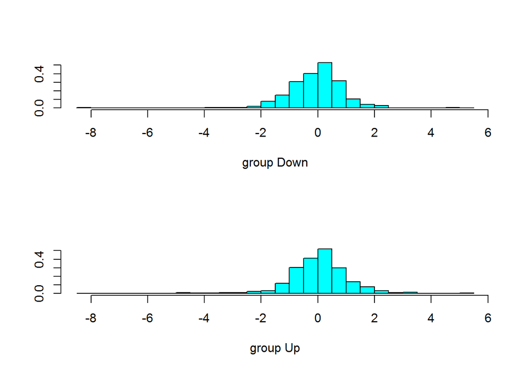

```r
#The plot() function produces plots of linear discriminants, obtained by multiplying Lag2 * 0.4877 for each of the
#training observation
plot(lda.fit)
```

```r
#The lda class returns a list of 3 elements ('class', 'posterior', 'x').
lda.pred=predict(lda.fit, Weekly.test)
#We are interested in the class element as it contains the LDA predictions about the movement of the market.
lda.class=lda.pred$class
#This produces the confusion matrix
table(lda.class, Direction.test)
```

```
##          Direction.test
## lda.class Down Up
##      Down    9  5
##      Up     34 56
```

```r
#The mean() function computes the fractions of days for which the prediction is correct
#For the training data
mean(lda.class!=Direction.test)
```

```
## [1] 0.375
```

```r
#For the test data
mean(lda.class==Direction.test)
```

```
## [1] 0.625
```

Question f) Repeat d) with QDA

The aim of this section is establish a QDA model has better performance predictions.

From the qda.fit result, we can conclude that:

1. 44.77% (Down) of the training observations correspond to days during which the market went down, and
2. 55.23% (Up) of the training observations correspond to days during which the market went up. The group means (average of the Lag2 predicator within each class) indicates that there is a tendency for day-2 (Lag2) to be positive (0.26) on days when the market increase and slightly negative (-0.035) when the market decrease.

Note: There is no coefficient of linear discriminant, because the QDA classifier involves a quadratic, rather than a linear, function of the predictors.

From the confusion matrix, provided below (i.e. table() function), we can deduce the model correctly predicts that the market would go up on 61 days and that it would go down 0 days on the test data, for a total of 61 days (61=61+0).

This is a strange result… In this case, it means the market is not predicted to go down… This is suspicious. It would be interesting to increase the training sample significantly and check whether the training model error rate improves.

```r
#I should not need to call this library again, as it is loaded as part of the 'LoadLibraries()' function.
#But for some reason it does not seem to load correctly the first time around and does not produce the LDA function.
#So this is a safety check.
library (MASS)
#The train, test and direction.test data do not need to be re-created as they have been generated in step d)
#This fits the QDA model using the subset argument set to the training dataset and the only predictor Lag2..
qda.fit = qda(Direction~Lag2, data=Weekly, subset=train)
qda.fit
```

```
## Call:
## qda(Direction ~ Lag2, data = Weekly, subset = train)
##
## Prior probabilities of groups:
##      Down        Up
## 0.4477157 0.5522843
##
## Group means:
##             Lag2
## Down -0.03568254
## Up    0.26036581
```

```r
#The qda class returns a list of 3 elements ('class', 'posterior', 'x').
qda.pred=predict(qda.fit, Weekly.test)
#We are interested in the class element as it contains the LDA predictions about the movement of the market.
qda.class=qda.pred$class
#This produces the confusion matrix
table(qda.class, Direction.test)
```

```
##          Direction.test
## qda.class Down Up
##      Down    0  0
##      Up     43 61
```

```r
#The mean() function computes the fractions of days for which the prediction is correct
#For the training data
mean(qda.class!=Direction.test)
```

```
## [1] 0.4134615
```

```r
#For the test data
mean(qda.class==Direction.test)
```

```
## [1] 0.5865385
```

Question g) Repeat d) with KNN where k=1

The aim of this section establishes a KNN model has better performance predictions.

From the confusion matrix provided below (i.e. table() function), we can deduce the model correctly predicts that the market would go up on 31 days and that it would go down 21 days, for a total of 52 days (52=31+21). The knn model can predict the movement of the market 50% of the time, on the test data. This is given by the mean() function.

```r
#We set the seed of the random number generator to ensure the results are repeatable.
set.seed(1)
#I should not need to call this library again, as it is loaded as part of the 'LoadLibraries()' function.
#But for some reason it does not seem to load correctly the first time around and does not produce the LDA function.
#So this is a safety check.
library (class)
#The train, test and direction.test data do not need to be re-created as they have been generated in step d)
#This is a matrix containing the predictors associated with the training data (train.X)
train.X = cbind(Lag2)[train,]
#This is a matrix containing the predictors associated with the data for which we wish to make predictions, labeled test.X
test.X = cbind(Lag2)[!train,]
length(train.X)
```

```
## [1] 985
```

```r
length(test.X)
```

```
## [1] 104
```

```r
#A vector containing the class labels for the training observations, labeled train.Direction
train.Direction = Direction[train]
#The Knn() function is used to predict the market's movement for the dates in the test set
#The value K corresponding to the nearest neighbours to be used by the classifier
knn.pred=knn(data.frame(train.X),data.frame(test.X),train.Direction, k=1)
#This is the confusion matrix
table(knn.pred, Direction.test)
```

```
##         Direction.test
## knn.pred Down Up
##     Down   21 30
##     Up     22 31
```

```r
#For the test data
mean(knn.pred==Direction.test)
```

```
## [1] 0.5
```

Question h) Which of these methods appears to provide the best results on this data?

Summary of the performance obtained with the studied models (and with the previously defined parameter selection):

- Logistic Regression: 62.5%
- LDA: 62.5%
- QDA: 58.65%
- KNN (K=1): 50%

It looks like the best performing models are the Logistic and LDA Regression models with a correct prediction rate of 62.5%. The worst performing model is the KNN where k=1 at 50%

Question i) Experiment with different combination of predictors, including possible transformations and interactions, for each of the methods. Reports the variables, method, and associated confusion matrix that appears to provide the best results on the held out data. Need to experiment with different values of K for KNN.

The Logistic Regression, LDA, QDA and KNN (k=1,k=2,k=5,k=10,k=20,k=30,k=40,k=50,k=60,k=69,k=70,k=80,k=90,k=100,k=150,k=200) models have been run against the following Response Vs Predicator variables:

- Direction Vs Lag2
- Direction Vs Lag2 and Volume
- Direction Vs Lag2^2
- Direction Vs Lag2^2 and Volume^2

Lag2 was still chosen as predictor as it seems to influence the model the most, then the Volume was chosen as an extra predictor.

```r
set.seed(1)
#Create a knn predictor wrapper function to improve code readability and maintenance
#It wrapps the knn(), table() and mean() function calls in one call
#It ensures the seed is always set to 1 for the random number generator
knn_predictor = function(train_dataset, test_dataset, train_direction, k_param){
  set.seed(1)
  knn.pred=knn(data.frame(train_dataset),data.frame(test_dataset),train_direction, k=k_param)
  #This is the confusion matrix
  table(knn.pred, Direction.test)
  #For the test data
  paste (" Accuracy Rate:", mean(knn.pred==Direction.test))
}

cat ("*****************************")
cat ("**** Glm Models")
```

```
## **** Glm Models
```

```r
cat ("*****************************")
glm.fit = glm(Direction~Lag2, data=Weekly,family=binomial)
glm.probs = predict(glm.fit,type="response")
glm.pred = rep("Down",length(Direction))
glm.pred[glm.probs>0.5]="Up"
table(glm.pred, Direction)
```

```
##         Direction
## glm.pred Down  Up
##     Down   33  26
##     Up    451 579
```

```r
cat ("GLM Direction~Lag2 Accuracy Rate: ", mean(glm.pred==Direction))
```

```
## GLM Direction~Lag2 Accuracy Rate:  0.5619835
```

```r
glm.fit = glm(Direction~Lag2+Volume, data=Weekly,family=binomial)
glm.probs = predict(glm.fit,type="response")
glm.pred = rep("Down",length(Direction))
glm.pred[glm.probs>0.5]="Up"
table(glm.pred, Direction)
```

```
##         Direction
## glm.pred Down  Up
##     Down   35  28
##     Up    449 577
```

```r
cat ("GLM Direction~Lag2+Volume Accuracy Rate: ", mean(glm.pred==Direction))
```

```
## GLM Direction~Lag2+Volume Accuracy Rate:  0.5619835
```

```r
glm.fit = glm(Direction~Lag2^2, data=Weekly,family=binomial)
glm.probs = predict(glm.fit,type="response")
glm.pred = rep("Down",length(Direction))
glm.pred[glm.probs>0.5]="Up"
table(glm.pred, Direction)
```

```
##         Direction
## glm.pred Down  Up
##     Down   33  26
##     Up    451 579
```

```r
cat ("GLM Direction~Lag2^2 Accuracy Rate: ", mean(glm.pred==Direction))
```

```
## GLM Direction~Lag2^2 Accuracy Rate:  0.5619835
```

```r
glm.fit = glm(Direction~Lag2^2+Volume^2, data=Weekly,family=binomial)
glm.probs = predict(glm.fit,type="response")
glm.pred = rep("Down",length(Direction))
glm.pred[glm.probs>0.5]="Up"
table(glm.pred, Direction)
```

```
##         Direction
## glm.pred Down  Up
##     Down   35  28
##     Up    449 577
```

```r
mean(glm.pred==Direction)
```

```
## [1] 0.5619835
```

```r
cat ("GLM Direction~Lag2^2+Volume^2 Accuracy Rate: ", mean(glm.pred==Direction))
```

```
## GLM Direction~Lag2^2+Volume^2 Accuracy Rate:  0.5619835
```

```r
cat ("*****************************")
cat ("Lda Models")
```

```
## Lda Models
```

```r
cat ("*****************************")
lda.fit = lda(Direction~Lag2, data=Weekly,subset=train)
lda.pred=predict(lda.fit, Weekly.test)
table(lda.class, Direction.test)
```

```
##          Direction.test
## lda.class Down Up
##      Down    9  5
##      Up     34 56
```

```r
cat ("LDA Direction~Lag2 Accuracy Rate: ", mean(lda.class==Direction.test))
```

```
## LDA Direction~Lag2 Accuracy Rate:  0.625
```

```r
lda.fit = lda(Direction~Lag2+Volume, data=Weekly,subset=train)
lda.pred=predict(lda.fit, Weekly.test)
table(lda.class, Direction.test)
```

```
##          Direction.test
## lda.class Down Up
##      Down    9  5
##      Up     34 56
```

```r
cat ("LDA Direction~Lag2+Volume Accuracy Rate: ", mean(lda.class==Direction.test))
```

```
## LDA Direction~Lag2+Volume Accuracy Rate:  0.625
```

```r
lda.fit = lda(Direction~Lag2^2+Volume, data=Weekly,subset=train)
lda.pred=predict(lda.fit, Weekly.test)
table(lda.class, Direction.test)
```

```
##          Direction.test
## lda.class Down Up
##      Down    9  5
##      Up     34 56
```

```r
cat ("LDA Direction~Lag2^2+Volume Accuracy Rate: ", mean(lda.class==Direction.test))
```

```
## LDA Direction~Lag2^2+Volume Accuracy Rate:  0.625
```

```r
lda.fit = lda(Direction~Lag2^2+Volume^2, data=Weekly,subset=train)
lda.pred=predict(lda.fit, Weekly.test)
table(lda.class, Direction.test)
```

```
##          Direction.test
## lda.class Down Up
##      Down    9  5
##      Up     34 56
```

```r
cat ("LDA Direction~Lag2^2+Volume^2 Accuracy Rate: ", mean(lda.class==Direction.test))
```

```
## LDA Direction~Lag2^2+Volume^2 Accuracy Rate:  0.625
```

```r
cat ("*****************************")
cat ("Qda Models")
```

```
## Qda Models
```

```r
cat ("*****************************")
qda.fit = qda(Direction~Lag2, data=Weekly, subset=train)
qda.pred=predict(qda.fit, Weekly.test)
qda.class=qda.pred$class
table(qda.class, Direction.test)
```

```
##          Direction.test
## qda.class Down Up
##      Down    0  0
##      Up     43 61
```

```r
mean(qda.class==Direction.test)
```

```
## [1] 0.5865385
```

```r
cat ("QDA Direction~Lag2 Accuracy Rate: ", mean(qda.class==Direction.test))
```

```
## QDA Direction~Lag2 Accuracy Rate:  0.5865385
```

```r
qda.fit = qda(Direction~Lag2+Volume, data=Weekly, subset=train)
qda.pred=predict(qda.fit, Weekly.test)
qda.class=qda.pred$class
table(qda.class, Direction.test)
```

```
##          Direction.test
## qda.class Down Up
##      Down   32 44
##      Up     11 17
```

```r
mean(qda.class==Direction.test)
```

```
## [1] 0.4711538
```

```r
cat ("QDA Direction~Lag2+Volume Accuracy Rate: ", mean(qda.class==Direction.test))
```

```
## QDA Direction~Lag2+Volume Accuracy Rate:  0.4711538
```

```r
qda.fit = qda(Direction~Lag2^2+Volume, data=Weekly, subset=train)
qda.pred=predict(qda.fit, Weekly.test)
qda.class=qda.pred$class
table(qda.class, Direction.test)
```

```
##          Direction.test
## qda.class Down Up
##      Down   32 44
##      Up     11 17
```

```r
mean(qda.class==Direction.test)
```

```
## [1] 0.4711538
```

```r
cat ("QDA Direction~Lag2^2+Volume Accuracy Rate: ", mean(qda.class==Direction.test))
```

```
## QDA Direction~Lag2^2+Volume Accuracy Rate:  0.4711538
```

```r
qda.fit = qda(Direction~Lag2^2+Volume^2, data=Weekly, subset=train)
qda.pred=predict(qda.fit, Weekly.test)
qda.class=qda.pred$class
table(qda.class, Direction.test)
```

```
##          Direction.test
## qda.class Down Up
##      Down   32 44
##      Up     11 17
```

```r
mean(qda.class==Direction.test)
```

```
## [1] 0.4711538
```

```r
cat ("QDA Direction~Lag2^2+Volume^2 Accuracy Rate: ", mean(qda.class==Direction.test))
```

```
## QDA Direction~Lag2^2+Volume^2 Accuracy Rate:  0.4711538
```

```r
cat ("*****************************")
cat ("KNN Models")
```

```
## KNN Models
```

```r
cat ("*****************************")
train.X = cbind(Lag2)[train,]
test.X = cbind(Lag2)[!train,]
knn_predictor(train.X, test.X, train.Direction, 1)
```

```
## [1] " Accuracy Rate: 0.5"
```

```r
knn_predictor(train.X, test.X, train.Direction, 2)
```

```
## [1] " Accuracy Rate: 0.509615384615385"
```

```r
knn_predictor(train.X, test.X, train.Direction, 5)
```

```
## [1] " Accuracy Rate: 0.538461538461538"
```

```r
knn_predictor(train.X, test.X, train.Direction, 10)
```

```
## [1] " Accuracy Rate: 0.548076923076923"
```

```r
knn_predictor(train.X, test.X, train.Direction, 20)
```

```
## [1] " Accuracy Rate: 0.586538461538462"
```

```r
Knn_Predictor(train.X, test.X, train.Direction, 30)
```

```
## [1] 0.5480769
```

```r
knn_predictor(train.X, test.X, train.Direction, 40)
```

```
## [1] " Accuracy Rate: 0.557692307692308"
```

```r
Knn_Predictor(train.X, test.X, train.Direction, 50)
```

```
## [1] 0.5576923
```

```r
knn_predictor(train.X, test.X, train.Direction, 60)
```

```
## [1] " Accuracy Rate: 0.567307692307692"
```

```r
knn_predictor(train.X, test.X, train.Direction, 69)
```

```
## [1] " Accuracy Rate: 0.586538461538462"
```

```r
knn_predictor(train.X, test.X, train.Direction, 70)
```

```
## [1] " Accuracy Rate: 0.567307692307692"
```

```r
Knn_Predictor(train.X, test.X, train.Direction, 80)
```

```
## [1] 0.5480769
```

```r
knn_predictor(train.X, test.X, train.Direction, 90)
```

```
## [1] " Accuracy Rate: 0.586538461538462"
```

```r
knn_predictor(train.X, test.X, train.Direction, 100)
```

```
## [1] " Accuracy Rate: 0.576923076923077"
```

```r
knn_predictor(train.X, test.X, train.Direction, 150)
```

```
## [1] " Accuracy Rate: 0.625"
```

```r
knn_predictor(train.X, test.X, train.Direction, 200)
```

```
## [1] " Accuracy Rate: 0.605769230769231"
```

```r
train.X = cbind(Lag2,Volume)[train,]
test.X = cbind(Lag2,Volume)[!train,]
knn_predictor(train.X, test.X, train.Direction, 1)
```

```
## [1] " Accuracy Rate: 0.557692307692308"
```

```r
knn_predictor(train.X, test.X, train.Direction, 2)
```

```
## [1] " Accuracy Rate: 0.557692307692308"
```

```r
knn_predictor(train.X, test.X, train.Direction, 5)
```

```
## [1] " Accuracy Rate: 0.528846153846154"
```

```r
knn_predictor(train.X, test.X, train.Direction, 10)
```

```
## [1] " Accuracy Rate: 0.461538461538462"
```

```r
knn_predictor(train.X, test.X, train.Direction, 20)
```

```
## [1] " Accuracy Rate: 0.509615384615385"
```

```r
Knn_Predictor(train.X, test.X, train.Direction, 30)
```

```
## [1] 0.5192308
```

```r
knn_predictor(train.X, test.X, train.Direction, 40)
```

```
## [1] " Accuracy Rate: 0.548076923076923"
```

```r
Knn_Predictor(train.X, test.X, train.Direction, 50)
```

```
## [1] 0.5480769
```

```r
knn_predictor(train.X, test.X, train.Direction, 60)
```

```
## [1] " Accuracy Rate: 0.586538461538462"
```

```r
knn_predictor(train.X, test.X, train.Direction, 69)
```

```
## [1] " Accuracy Rate: 0.567307692307692"
```

```r
knn_predictor(train.X, test.X, train.Direction, 70)
```

```
## [1] " Accuracy Rate: 0.567307692307692"
```

```r
Knn_Predictor(train.X, test.X, train.Direction, 80)
```

```
## [1] 0.5576923
```

```r
knn_predictor(train.X, test.X, train.Direction, 90)
```

```
## [1] " Accuracy Rate: 0.586538461538462"
```

```r
knn_predictor(train.X, test.X, train.Direction, 100)
```

```
## [1] " Accuracy Rate: 0.596153846153846"
```

```r
knn_predictor(train.X, test.X, train.Direction, 150)
```

```
## [1] " Accuracy Rate: 0.634615384615385"
```

```r
knn_predictor(train.X, test.X, train.Direction, 200)
```

```
## [1] " Accuracy Rate: 0.605769230769231"
```

```r
train.X = cbind(Lag2^2)[train,]
test.X = cbind(Lag2^2)[!train,]
knn_predictor(train.X, test.X, train.Direction, 1)
```

```
## [1] " Accuracy Rate: 0.5"
```

```r
knn_predictor(train.X, test.X, train.Direction, 2)
```

```
## [1] " Accuracy Rate: 0.538461538461538"
```

```r
knn_predictor(train.X, test.X, train.Direction, 5)
```

```
## [1] " Accuracy Rate: 0.442307692307692"
```

```r
knn_predictor(train.X, test.X, train.Direction, 10)
```

```
## [1] " Accuracy Rate: 0.490384615384615"
```

```r
knn_predictor(train.X, test.X, train.Direction, 20)
```

```
## [1] " Accuracy Rate: 0.548076923076923"
```

```r
Knn_Predictor(train.X, test.X, train.Direction, 30)
```

```
## [1] 0.625
```

```r
knn_predictor(train.X, test.X, train.Direction, 40)
```

```
## [1] " Accuracy Rate: 0.528846153846154"
```

```r
Knn_Predictor(train.X, test.X, train.Direction, 50)
```

```
## [1] 0.5480769
```

```r
knn_predictor(train.X, test.X, train.Direction, 60)
```

```
## [1] " Accuracy Rate: 0.567307692307692"
```

```r
knn_predictor(train.X, test.X, train.Direction, 69)
```

```
## [1] " Accuracy Rate: 0.567307692307692"
```

```r
knn_predictor(train.X, test.X, train.Direction, 70)
```

```
## [1] " Accuracy Rate: 0.567307692307692"
```

```r
Knn_Predictor(train.X, test.X, train.Direction, 80)
```

```
## [1] 0.5480769
```

```r
knn_predictor(train.X, test.X, train.Direction, 90)
```

```
## [1] " Accuracy Rate: 0.567307692307692"
```

```r
knn_predictor(train.X, test.X, train.Direction, 100)
```

```
## [1] " Accuracy Rate: 0.596153846153846"
```

```r
knn_predictor(train.X, test.X, train.Direction, 150)
```

```
## [1] " Accuracy Rate: 0.596153846153846"
```

```r
knn_predictor(train.X, test.X, train.Direction, 200)
```

```
## [1] " Accuracy Rate: 0.586538461538462"
```

```r
train.X = cbind(Lag2^2,Volume^2)[train,]
test.X = cbind(Lag2^2,Volume^2)[!train,]
knn_predictor(train.X, test.X, train.Direction, 1)
```

```
## [1] " Accuracy Rate: 0.442307692307692"
```

```r
knn_predictor(train.X, test.X, train.Direction, 2)
```

```
## [1] " Accuracy Rate: 0.509615384615385"
```

```r
knn_predictor(train.X, test.X, train.Direction, 5)
```

```
## [1] " Accuracy Rate: 0.480769230769231"
```

```r
knn_predictor(train.X, test.X, train.Direction, 10)
```

```
## [1] " Accuracy Rate: 0.451923076923077"
```

```r
knn_predictor(train.X, test.X, train.Direction, 20)
```

```
## [1] " Accuracy Rate: 0.442307692307692"
```

```r
Knn_Predictor(train.X, test.X, train.Direction, 30)
```

```
## [1] 0.4326923
```

```r
knn_predictor(train.X, test.X, train.Direction, 40)
```

```
## [1] " Accuracy Rate: 0.442307692307692"
```

```r
Knn_Predictor(train.X, test.X, train.Direction, 50)
```

```
## [1] 0.5384615
```

```r
knn_predictor(train.X, test.X, train.Direction, 60)
```

```
## [1] " Accuracy Rate: 0.509615384615385"
```

```r
knn_predictor(train.X, test.X, train.Direction, 69)
```

```
## [1] " Accuracy Rate: 0.432692307692308"
```

```r
knn_predictor(train.X, test.X, train.Direction, 70)
```

```
## [1] " Accuracy Rate: 0.461538461538462"
```

```r
Knn_Predictor(train.X, test.X, train.Direction, 80)
```

```
## [1] 0.4903846
```

```r
knn_predictor(train.X, test.X, train.Direction, 90)
```

```
## [1] " Accuracy Rate: 0.490384615384615"
```

```r
knn_predictor(train.X, test.X, train.Direction, 100)
```

```
## [1] " Accuracy Rate: 0.605769230769231"
```

```r
knn_predictor(train.X, test.X, train.Direction, 150)
```

```
## [1] " Accuracy Rate: 0.586538461538462"
```

```r
knn_predictor(train.X, test.X, train.Direction, 200)
```

```
## [1] " Accuracy Rate: 0.586538461538462"
```

Exercise 12: Create wrapper functions

Question a) Write a function Power() that raises 2 to the 3rd power

```r
Power= function (){
  result = 2^3 #calculate and return the result
  paste("result:", toString(result),sep= " ") #just a screen print out
}
#Call the function
Power()
```

```
## [1] "result: 8"
```

Question b) Write a function Power2(x,a), that allows to pass any two numbers and prints out x^a

```r
Power2= function (x, a){
  result = x^a #calculate and return the result
  paste("Input:",toString(x),
        "Power^:",toString(a),
        "result:", toString(result),
        sep= " ") #just a screen print out
}
Power2(3, 8)
```

```
## [1] "Input: 3 Power^: 8 result: 6561"
```

Question c) Using Power2(x,a), compute a 10^3, 8^17, 131^3

```r
#Call the function 3 times with different examples
Power2(10.0,3.0)
```

```
## [1] "Input: 10 Power^: 3 result: 1000"
```

```r
Power2(8.0,17.0)
```

```
## [1] "Input: 8 Power^: 17 result: 2251799813685248"
```

```r
Power2(131.0,3.0)
```

```
## [1] "Input: 131 Power^: 3 result: 2248091"
```

Question d) Create Power3(x,a) that returns the returns x^a as an R object

```r
Power3= function (x, a){
  result = x^a #the result object
  return (result) # the result object being returned
}
```

Question e) Using Power3(x,a) create a plot of f(x)= x^2

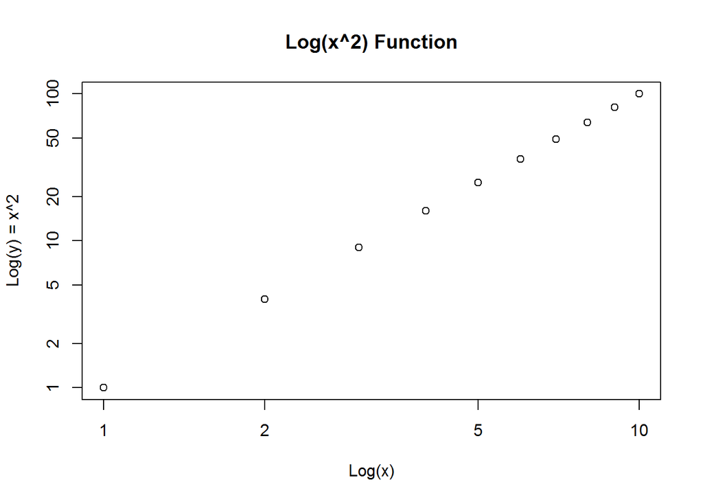

```r
x = 1:10
plot( x, #x values between 1 and 10 on the x-axis
      Power3(x, 2), #function return x^2 on the y-axis
      log = "xy", #both axis are shown as log-scale
      ylab = "Log(y) = x^2", #y label
      xlab = "Log(x)", #x label
      main = "Log(x^2) Function") #main title
```

Question f) Create a function that allows to create plot of x against x^3 for a fixed and range value of x

```
## [1]   1   4   9  16  25  36  64  81 100
```

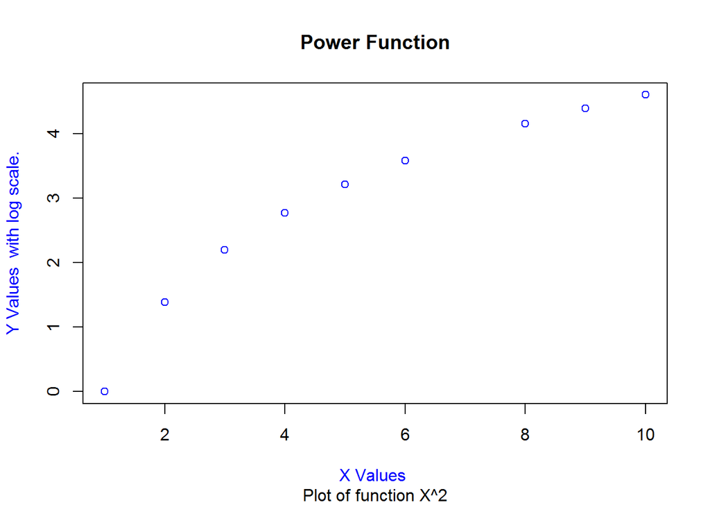

```r
# x is the input data, a is the power and log indicates whether the x axis should use log scale (log='x'),
# or the y axis should use the log scale (log='y') or both axis should use log scale (log='xy')
PlotPower= function (x, a, log='y'){

    #create an empty vector
    y = c()
    #get the vector length
    len = length(x)

    #this is a check to ensure the user pass a vector containing at list one element
    if (len == 0)
      stop ("input cannot be null")

    #for each of element in the input vector, elevate the element 'x[i]' to the power 'a'
    for (i in 1:len)
      y[i] = c(Power3(x[i], a ))

    #print the result
    print(y)

    #reset x and/or y depending on the log parameter passed in the function
    #if a none supported parameter is passed, then neither x nor y will be scaled.
    xLog = ""
    yLog = ""
    if (log=='y') {y=log(y); yLog = ' with log scale.'}
    if (log=='x') {x=log(x); xLog = ' with log scale.'}
    if (log=='xy') {x=log(x);y=log(y); yLog = ' with log scale.'; xLog = ' with log scale.'}

    #plot the data
    plot( x,y, # the input (x) and output (y)
          main="Power Function",sub=paste("Plot of function X^", a, sep=""), #main and customisable  sub title
          xlab=paste("X Values", xLog, sep =" ") , #x customisable label name
          ylab=paste("Y Values", yLog, sep =" "), #y customisable label name
          col="blue", # curve color
          col.lab="blue", #color of the labels
          col.axis="black", # color of the axis
          pch=1) #the shape of the points in the plot
    }


#plot the data for the defined input c(...) raise to the power 2. There are 4 scenarios, one for each log parameter case.
PlotPower(c(1,2,3,4,5,6,8,9,10), 2, 'y')
```

```
## [1]   1   4   9  16  25  36  64  81 100
```

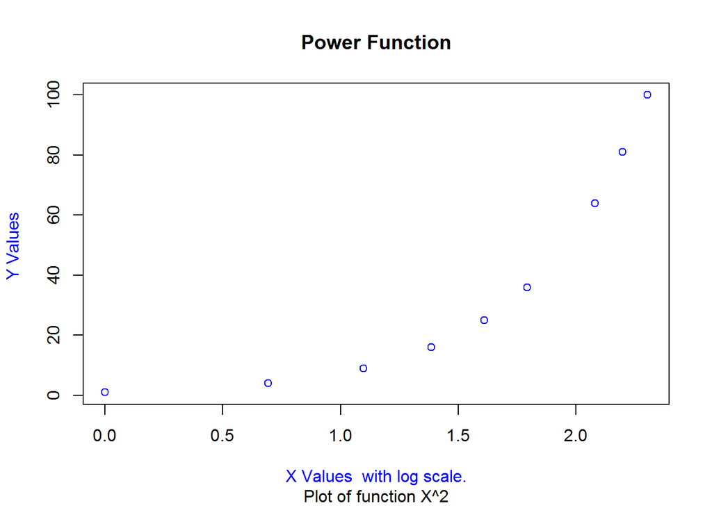

```r
PlotPower(c(1,2,3,4,5,6,8,9,10), 2, 'x')
```

```
## [1]   1   4   9  16  25  36  64  81 100
```

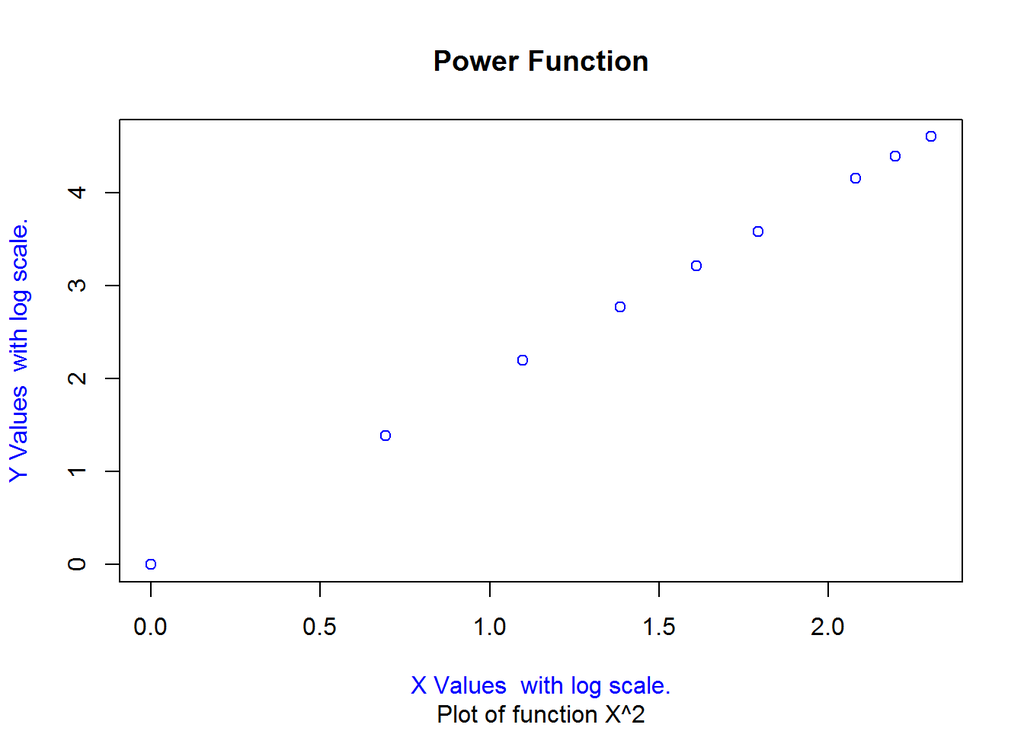

```r
PlotPower(c(1,2,3,4,5,6,8,9,10), 2, 'xy')
```

```
## [1]   1   4   9  16  25  36  64  81 100
```

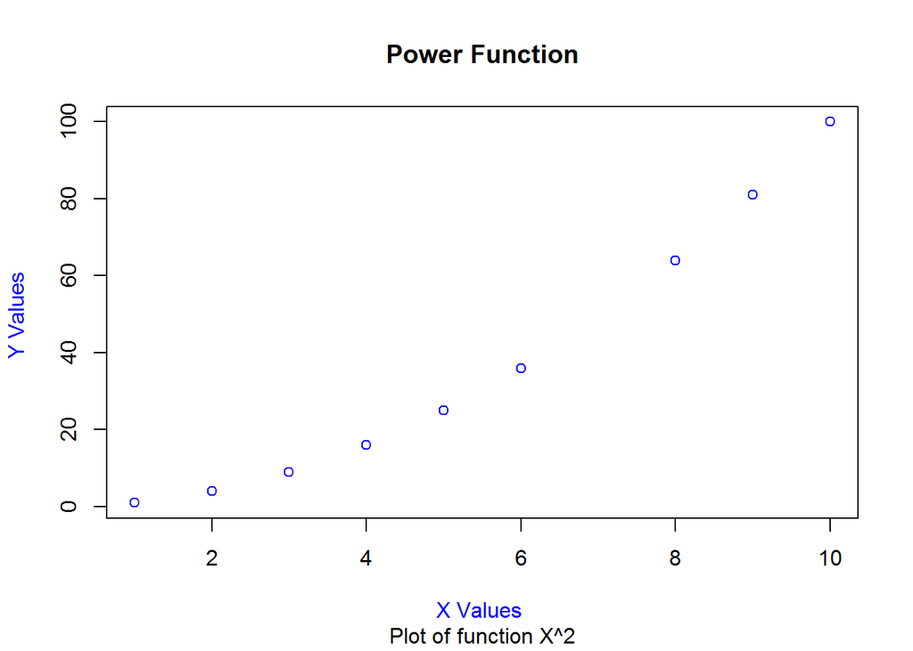

```r
PlotPower(c(1,2,3,4,5,6,8,9,10), 2, 'dummy')
```

```
## [1] 125
```

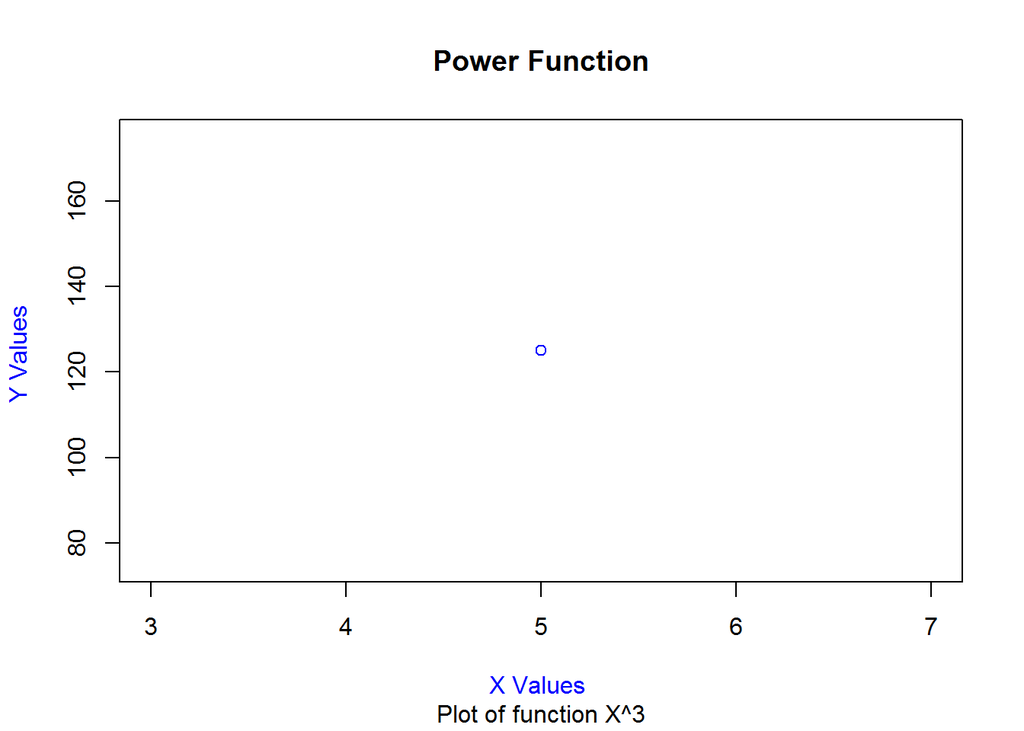

```r
#plot the data for a unique x value use case
PlotPower2(5, 3, 'dummy')
```

```
##  [1]    1    8   27   64  125  216  343  512  729 1000
```

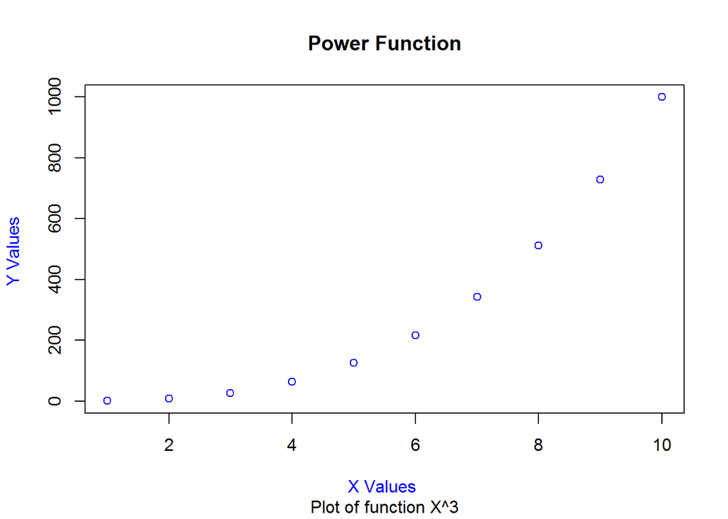

```r
#plot the data for range value of x
PlotPower2(1:10, 3, 'dummy') #range case
```

## Week 7 - Classification: Linear Discriminant Analysis, Quadratic Discriminant Analysis, Naïve Bayes

Exercise 11: Develop a model to predict whether a given car gets high or low gas mileage based on the auto dataset.

Question a) Create a binary variable, that contains ‘1’ when mpg contains a value > median, else ‘0’.

```r
library(ISLR)
#reload the original dataset to start from a clean position
data("Auto")
#Remove Weekly from the search() path of R object
detach(Auto)
#The database is searched by R when evaluating a variable,
#so objects in the database can be accessed by simply giving their names.
attach(Auto)
```

```r
#view r the data in a grid
fix(Auto)

#Clean-up. This is necessary as the script may be run more than once. It is necessary to ensure there is only one version of this column
if("mpg01" %in% colnames(Auto))
{
  Auto$mpg01<-NULL
  cat ("mpg01 deleted from Auto")
}

#The median is assumed to be strictly above the median
Auto$mpg01 = ifelse(Auto$mpg > median(Auto$mpg),1,0)
cat ("mpg01 created in Auto")
```

```
## mpg01 created in Auto
```

Question b) Explore the data graphically in order to investigate the association between mpg01 and the other features. In other words, what other features seem most likely to be useful in predicting mpg01?

From the box plots and the plots below, it is not possible to draw any interesting conclusion relative to mpg01 (as this is a boolean variable).

The same comment can be made about the graphs generated by the pairs() function. Therefore, mpg instead of mpg01 is used for this analysis. It looks like mpg is negatively correlated with displacement, horsepower and weight. It also seems that mpg is slightly positively correlated with origin and year.

The cor() function provides more readable information about mpg01 in relation to the other predicators. Mpg01 is negatively correlated with displacement, horsepower and weight and also with cylinders. Mpg01 seems slightly positively correlated with origin and year.

Furthermore, if 0.5 is assumed to be the correlation cut of point, then the year variable could be discarded as a feature useful in predicating, as it displays an absolute correlation value strictly less than 0.5.  
Mpg seems also strongly correlated with mpg (but this is obvious as mpg01 derives from mpg).

Therefore, from this analysis the feature that seems to be the most influential for predicting the mpg01 level are: cylinders, displacement, horsepower, weight and origin. As they display an absolute value correlation with mmpg01 greater than 0.5.

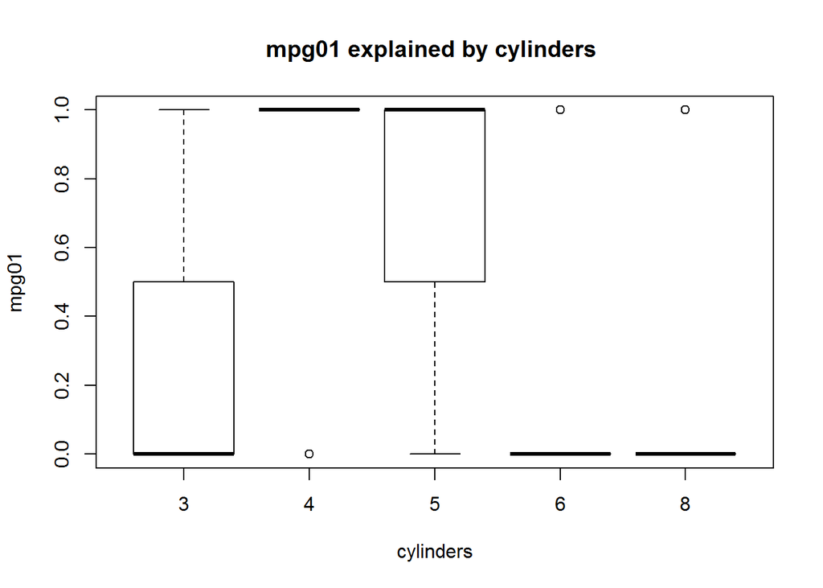

```r
#Boxplots
boxplot(mpg01~cylinders, main="mpg01 explained by cylinders ", xlab="cylinders",ylab="mpg01")
```

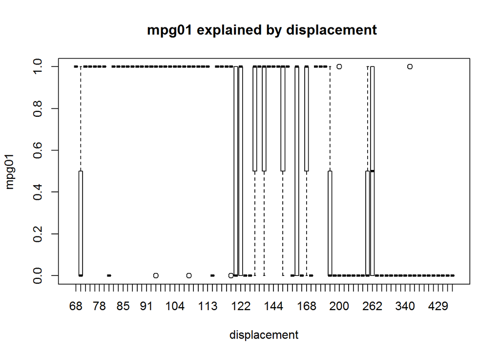

```r
boxplot(mpg01~displacement, main="mpg01 explained by displacement ", xlab="displacement",ylab="mpg01")
```

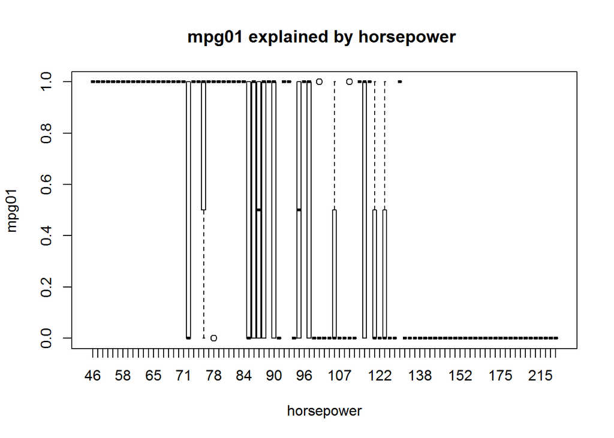

```r
boxplot(mpg01~horsepower, main="mpg01 explained by horsepower ", xlab="horsepower",ylab="mpg01")
```

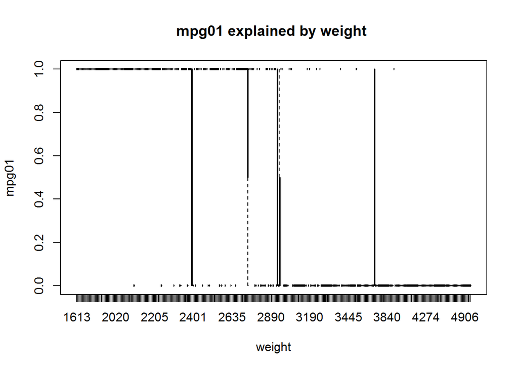

```r
boxplot(mpg01~weight, main="mpg01 explained by weight ", xlab="weight",ylab="mpg01")
```

[figure not shown]

```r
boxplot(mpg01~acceleration, main="mpg01 explained by Cylinders ", xlab="Cylinders",ylab="mpg01")
```

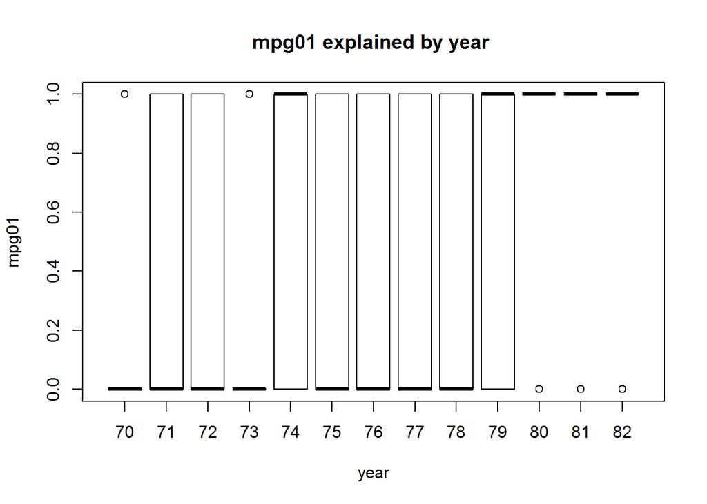

```r
boxplot(mpg01~year, main="mpg01 explained by year ", xlab="year",ylab="mpg01")
```

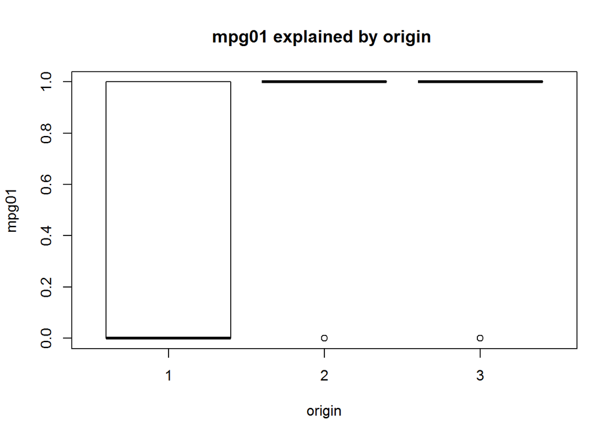

```r
boxplot(mpg01~origin, main="mpg01 explained by origin ", xlab="origin",ylab="mpg01")
```

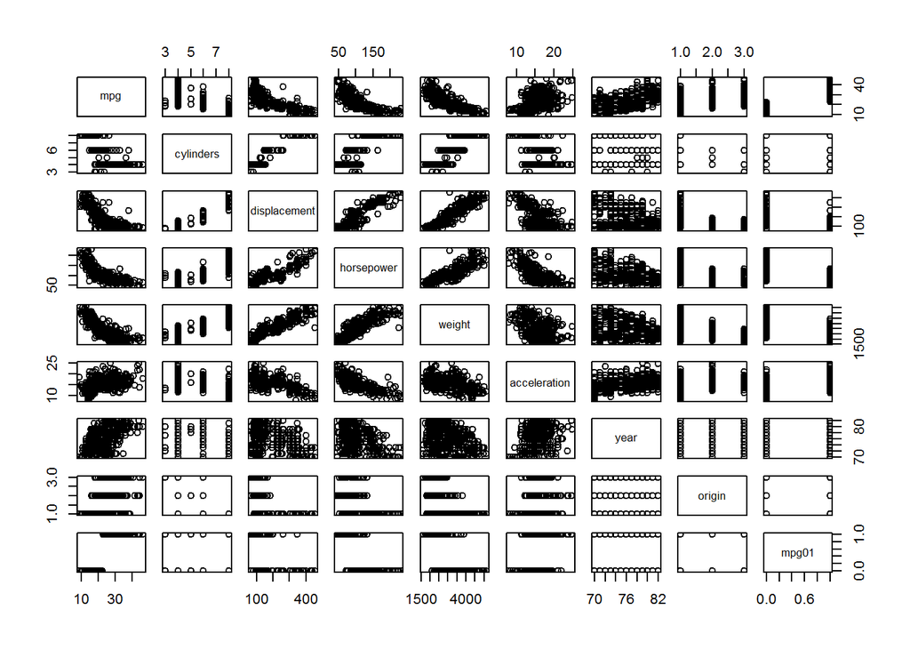

```r
#It produces a matrix of scatter plots
pairs(Auto[,-9])
```

```r
#Display the correlation pairs
cor(Auto[,-9])
```

```
##                     mpg  cylinders displacement horsepower     weight
## mpg           1.0000000 -0.7776175   -0.8051269 -0.7784268 -0.8322442
## cylinders    -0.7776175  1.0000000    0.9508233  0.8429834  0.8975273
## displacement -0.8051269  0.9508233    1.0000000  0.8972570  0.9329944
## horsepower   -0.7784268  0.8429834    0.8972570  1.0000000  0.8645377
## weight       -0.8322442  0.8975273    0.9329944  0.8645377  1.0000000
## acceleration  0.4233285 -0.5046834   -0.5438005 -0.6891955 -0.4168392
## year          0.5805410 -0.3456474   -0.3698552 -0.4163615 -0.3091199
## origin        0.5652088 -0.5689316   -0.6145351 -0.4551715 -0.5850054
## mpg01         0.8369392 -0.7591939   -0.7534766 -0.6670526 -0.7577566
##              acceleration       year     origin      mpg01
## mpg             0.4233285  0.5805410  0.5652088  0.8369392
## cylinders      -0.5046834 -0.3456474 -0.5689316 -0.7591939
## displacement   -0.5438005 -0.3698552 -0.6145351 -0.7534766
## horsepower     -0.6891955 -0.4163615 -0.4551715 -0.6670526
## weight         -0.4168392 -0.3091199 -0.5850054 -0.7577566
## acceleration    1.0000000  0.2903161  0.2127458  0.3468215
## year            0.2903161  1.0000000  0.1815277  0.4299042
## origin          0.2127458  0.1815277  1.0000000  0.5136984
## mpg01           0.3468215  0.4299042  0.5136984  1.0000000
```

Question c) Split the data between training and test sets.

It is assumed that approx. 50% of the data serve as training data and 50% serve as test data. The code below shows the split.

```r
train = (year<77)
test = !train
Auto.train = Auto[train, ]
Auto.test = Auto[test, ]
mpg01.test = mpg01[test]
train_size = dim(Auto.train)[1]
test_size = dim(Auto.test)[1]
total = dim(Auto)[1]
train_size
```

```
## [1] 214
```

```r
train_ratio = 100.0 * (train_size/total);
paste ("exact training ratio:", train_ratio, sep = " ")
```

```
## [1] "exact training ratio: 54.5918367346939"
```

```r
test_ratio = 100.0 * (test_size/total);
paste ("exact test ratio:", test_ratio, sep = " ")
```

```
## [1] "exact test ratio: 45.4081632653061"
```

Question d) Perform a LDA on the training data using variables that seemed most associated with mpg01. What is the test error obtained?

The test error obtained in the mean() function is 12.36%

```r
# LDA
# load the library for LDA
library(MASS)
#Generate the fitting model
lda.fit = lda(mpg01 ~ cylinders + weight + displacement + horsepower + origin, data = Auto, subset = train)
#Generate the prediction model
lda.pred = predict(lda.fit, Auto.test)
#Compare prediction on the test data vs the expected test value. The result of the mean represents the error rate
mean(lda.pred$class != mpg01.test)
```

```
## [1] 0.1235955
```

Question e) Perform a QDA on the training data using variables that seemed most associated with mpg01. What is the test error obtained?

The test error obtained in the mean() function is 12.36%

```r
#QDA
# load the library for LDA
library(MASS)
#Generate the fitting model
qda.fit = qda(mpg01~ cylinders + weight + displacement + horsepower + origin, data = Auto, subset = train)
#Generate the prediction model
qda.pred = predict(qda.fit, Auto.test)
#Compare prediction on the test data vs the expected test value. The result of the mean represents the error rate
mean(qda.pred$class != mpg01.test)
```

```
## [1] 0.1235955
```

Question f) Perform a Logistic Regression on the training data using variables that seemed most associated with mpg01. What is the test error obtained?

The test error obtained in the mean() function is 20.79%

```r
# Logistic regression with the family is binomial (i.e. the error distribution and link function to be used in the model), in other words using the logit
glm.fit = glm(mpg01~ cylinders + weight + displacement + horsepower + origin, data = Auto, family = binomial, subset = train)
#TODO explain
glm.probs = predict(glm.fit, Auto.test, type = "response")
#TODO explain
glm.pred = rep(0, length(glm.probs))
glm.pred[glm.probs > 0.5] = 1
mean(glm.pred != mpg01.test)
```

```
## [1] 0.2078652
```

Question g) Perform a KNN using variables that seemed most associated with mpg01. What is the test error obtained? What is the value of K that seems to perform best on this data set?

```r
library(class)
#Create a training vector set
train.X = cbind(cylinders, weight, displacement, horsepower, origin)[train, ]
#Create a test vector set
test.X = cbind(cylinders, weight, displacement, horsepower, origin)[test, ]
#TODO explain
train.mpg01 = mpg01[train]
#set to the random variable seed to ensure reproductivity
set.seed(1)
#As the number of patters is 278, K will vary between 1 and 278
# KNN(k=1)
knn.pred = knn(train.X, test.X, train.mpg01, k = 1)
mean(knn.pred != mpg01.test)
```

```
## [1] 0.1853933
```

```r
# KNN(k=10)
knn.pred = knn(train.X, test.X, train.mpg01, k = 10)
mean(knn.pred != mpg01.test)
```

```
## [1] 0.1741573
```

```r
# KNN(k=50)
knn.pred = knn(train.X, test.X, train.mpg01, k = 50)
mean(knn.pred != mpg01.test)
```

```
## [1] 0.2303371
```

```r
# KNN(k=100)
knn.pred = knn(train.X, test.X, train.mpg01, k = 100)
mean(knn.pred != mpg01.test)
```

```
## [1] 0.1797753
```

```r
# KNN(k=200)
knn.pred = knn(train.X, test.X, train.mpg01, k = 200)
mean(knn.pred != mpg01.test)
```

```
## [1] 0.6966292
```

Exercise 13: Using the Boston data set, fit classification models in order to predict whether a given suburb has a crime rate above or below the median. Explore Logistic Regression, LDA, KNN models using various subsets of predictors.

First, let’s create the crime01 col

```r
library(MASS)
#reload the original dataset to start from a clean position
data("Boston")
detach(Boston)
attach(Boston)

#Clean-up. This is necessary as the script may be run more than once.
#It is necessary to ensure there is only one version of this column
if("crime01" %in% colnames(Boston))
{
  Boston$crime01<-NULL
  cat ("crime01 deleted from Boston")
}
#Above the median is understood as strictly greater than the median
crime01 = rep(0, length(crim))
#The crime001 column displays 1 when the crime rate is above the median, else it displays 0
crime01[crim > median(crim)] = 1

Boston = data.frame(Boston, crime01)
cat ("crime01 is now attached to the Boston dataset")
```

```
## crime01 is now attached to the Boston dataset
```

```r
#The training dataset set is set to 50% of the Boston data
train = 1:(dim(Boston)[1] * 0.5)
#The test dataset set is set to 50% of the Boston data
test = (dim(Boston)[1]*0.5 + 1):dim(Boston)[1]
Boston.train = Boston[train, ]
Boston.test = Boston[test, ]
crime01.test = crime01[test]
```

Second, let’s have a look at the potential significance of variables. For that, plots and a correlation table are produced. We will assume that abs(0.5) is the correlation cut off point. Any predictor with a correlation level above the cut off is considered as significantly impacting crime01.

Consequently, looking at the correlation table, we will retain the following explanatory variable in our model: indus (0.603),nox(0.723),age(0.614), dis(-0.616), rad(0.6197), tax(0.609).

It looks like all these variables part from dis, have a positive relationship with crm01. Dis has a negative relationship. We start with this list as a base case and then modify the predictor list to see whether we can improve on the model test performance.

```r
summary(Boston)
```

```
##       crim                zn             indus            chas
##  Min.   : 0.00632   Min.   :  0.00   Min.   : 0.46   Min.   :0.00000
##  1st Qu.: 0.08204   1st Qu.:  0.00   1st Qu.: 5.19   1st Qu.:0.00000
##  Median : 0.25651   Median :  0.00   Median : 9.69   Median :0.00000
##  Mean   : 3.61352   Mean   : 11.36   Mean   :11.14   Mean   :0.06917
##  3rd Qu.: 3.67708   3rd Qu.: 12.50   3rd Qu.:18.10   3rd Qu.:0.00000
##  Max.   :88.97620   Max.   :100.00   Max.   :27.74   Max.   :1.00000
##       nox               rm             age              dis
##  Min.   :0.3850   Min.   :3.561   Min.   :  2.90   Min.   : 1.130
##  1st Qu.:0.4490   1st Qu.:5.886   1st Qu.: 45.02   1st Qu.: 2.100
##  Median :0.5380   Median :6.208   Median : 77.50   Median : 3.207
##  Mean   :0.5547   Mean   :6.285   Mean   : 68.57   Mean   : 3.795
##  3rd Qu.:0.6240   3rd Qu.:6.623   3rd Qu.: 94.08   3rd Qu.: 5.188
##  Max.   :0.8710   Max.   :8.780   Max.   :100.00   Max.   :12.127
##       rad              tax           ptratio          black
##  Min.   : 1.000   Min.   :187.0   Min.   :12.60   Min.   :  0.32
##  1st Qu.: 4.000   1st Qu.:279.0   1st Qu.:17.40   1st Qu.:375.38
##  Median : 5.000   Median :330.0   Median :19.05   Median :391.44
##  Mean   : 9.549   Mean   :408.2   Mean   :18.46   Mean   :356.67
##  3rd Qu.:24.000   3rd Qu.:666.0   3rd Qu.:20.20   3rd Qu.:396.23
##  Max.   :24.000   Max.   :711.0   Max.   :22.00   Max.   :396.90
##      lstat            medv          crime01
##  Min.   : 1.73   Min.   : 5.00   Min.   :0.0
##  1st Qu.: 6.95   1st Qu.:17.02   1st Qu.:0.0
##  Median :11.36   Median :21.20   Median :0.5
##  Mean   :12.65   Mean   :22.53   Mean   :0.5
##  3rd Qu.:16.95   3rd Qu.:25.00   3rd Qu.:1.0
##  Max.   :37.97   Max.   :50.00   Max.   :1.0
```

```r
cor(Boston)
```

```
##                crim          zn       indus         chas         nox
## crim     1.00000000 -0.20046922  0.40658341 -0.055891582  0.42097171
## zn      -0.20046922  1.00000000 -0.53382819 -0.042696719 -0.51660371
## indus    0.40658341 -0.53382819  1.00000000  0.062938027  0.76365145
## chas    -0.05589158 -0.04269672  0.06293803  1.000000000  0.09120281
## nox      0.42097171 -0.51660371  0.76365145  0.091202807  1.00000000
## rm      -0.21924670  0.31199059 -0.39167585  0.091251225 -0.30218819
## age      0.35273425 -0.56953734  0.64477851  0.086517774  0.73147010
## dis     -0.37967009  0.66440822 -0.70802699 -0.099175780 -0.76923011
## rad      0.62550515 -0.31194783  0.59512927 -0.007368241  0.61144056
## tax      0.58276431 -0.31456332  0.72076018 -0.035586518  0.66802320
## ptratio  0.28994558 -0.39167855  0.38324756 -0.121515174  0.18893268
## black   -0.38506394  0.17552032 -0.35697654  0.048788485 -0.38005064
## lstat    0.45562148 -0.41299457  0.60379972 -0.053929298  0.59087892
## medv    -0.38830461  0.36044534 -0.48372516  0.175260177 -0.42732077
## crime01  0.40939545 -0.43615103  0.60326017  0.070096774  0.72323480
##                  rm         age         dis          rad         tax
## crim    -0.21924670  0.35273425 -0.37967009  0.625505145  0.58276431
## zn       0.31199059 -0.56953734  0.66440822 -0.311947826 -0.31456332
## indus   -0.39167585  0.64477851 -0.70802699  0.595129275  0.72076018
## chas     0.09125123  0.08651777 -0.09917578 -0.007368241 -0.03558652
## nox     -0.30218819  0.73147010 -0.76923011  0.611440563  0.66802320
## rm       1.00000000 -0.24026493  0.20524621 -0.209846668 -0.29204783
## age     -0.24026493  1.00000000 -0.74788054  0.456022452  0.50645559
## dis      0.20524621 -0.74788054  1.00000000 -0.494587930 -0.53443158
## rad     -0.20984667  0.45602245 -0.49458793  1.000000000  0.91022819
## tax     -0.29204783  0.50645559 -0.53443158  0.910228189  1.00000000
## ptratio -0.35550149  0.26151501 -0.23247054  0.464741179  0.46085304
## black    0.12806864 -0.27353398  0.29151167 -0.444412816 -0.44180801
## lstat   -0.61380827  0.60233853 -0.49699583  0.488676335  0.54399341
## medv     0.69535995 -0.37695457  0.24992873 -0.381626231 -0.46853593
## crime01 -0.15637178  0.61393992 -0.61634164  0.619786249  0.60874128
##            ptratio       black      lstat       medv     crime01
## crim     0.2899456 -0.38506394  0.4556215 -0.3883046  0.40939545
## zn      -0.3916785  0.17552032 -0.4129946  0.3604453 -0.43615103
## indus    0.3832476 -0.35697654  0.6037997 -0.4837252  0.60326017
## chas    -0.1215152  0.04878848 -0.0539293  0.1752602  0.07009677
## nox      0.1889327 -0.38005064  0.5908789 -0.4273208  0.72323480
## rm      -0.3555015  0.12806864 -0.6138083  0.6953599 -0.15637178
## age      0.2615150 -0.27353398  0.6023385 -0.3769546  0.61393992
## dis     -0.2324705  0.29151167 -0.4969958  0.2499287 -0.61634164
## rad      0.4647412 -0.44441282  0.4886763 -0.3816262  0.61978625
## tax      0.4608530 -0.44180801  0.5439934 -0.4685359  0.60874128
## ptratio  1.0000000 -0.17738330  0.3740443 -0.5077867  0.25356836
## black   -0.1773833  1.00000000 -0.3660869  0.3334608 -0.35121093
## lstat    0.3740443 -0.36608690  1.0000000 -0.7376627  0.45326273
## medv    -0.5077867  0.33346082 -0.7376627  1.0000000 -0.26301673
## crime01  0.2535684 -0.35121093  0.4532627 -0.2630167  1.00000000
```

From the below test performance, it appears that the best result is obtained when test MSE is 10.28%. Even when we affect the polynomial of the main explanatory variable (square root and square).

This model tells us that the concentration level of nitrogen oxides plays the greatest part in the level of crime. This is an interesting insight.

```r
#We set the seed to 1 to ensure repeatability
set.seed(1)
#Create a gml wrapper for code reuse and maintenance reduction
glm_performance = function(the_fit, msg){
  glm.probs = predict(the_fit, Boston.test, type = "response")
  glm.pred = rep(0, length(glm.probs))
  glm.pred[glm.probs > 0.5] = 1

  paste("Test MSE: ", round(100 * mean(glm.pred != crime01.test),digits=2) ,"% with ", msg  )
}

#***** Logistic Regression
# Logistic regression with the family is binomial  (i.e. the error distribution and link function to be used in the model), in other words using the logit

glm.fit = glm(crime01 ~ nox+rad+dis+age+tax, indus, data = Boston, family = binomial, subset = train)
glm_performance(glm.fit, "crime01 ~ nox+rad+dis+age+tax+indus")
```

```
## [1] "Test MSE:  11.07 % with  crime01 ~ nox+rad+dis+age+tax+indus"
```

```r
glm.fit = glm(crime01 ~ nox,data = Boston, family = binomial, subset = train)
glm_performance(glm.fit, "crime01 ~ nox")
```

```
## [1] "Test MSE:  11.07 % with  crime01 ~ nox"
```

```r
glm.fit = glm(crime01 ~ nox+rad, data = Boston, family = binomial, subset = train)
glm_performance(glm.fit, "crime01 ~ nox+rad")
```

```
## [1] "Test MSE:  10.28 % with  crime01 ~ nox+rad"
```

```r
glm.fit = glm(crime01 ~ nox+rad+dis, data = Boston, family = binomial, subset = train)
glm_performance(glm.fit, "crime01 ~ nox+rad+dis")
```

```
## [1] "Test MSE:  10.28 % with  crime01 ~ nox+rad+dis"
```

```r
glm.fit = glm(crime01 ~ nox+rad+dis+age, data = Boston, family = binomial, subset = train)
glm_performance(glm.fit, "crime01 ~ nox+rad+dis+age")
```

```
## [1] "Test MSE:  10.28 % with  crime01 ~ nox+rad+dis+age"
```

```r
glm.fit = glm(crime01 ~ nox+rad+dis+age, data = Boston, family = binomial, subset = train)
glm_performance(glm.fit, "crime01 ~ nox+rad+dis+age+tax")
```

```
## [1] "Test MSE:  10.28 % with  crime01 ~ nox+rad+dis+age+tax"
```

```r
glm.fit = glm(crime01 ~ nox^2,data = Boston, family = binomial, subset = train)
glm_performance(glm.fit, "crime01 ~ nox^2")
```

```
## [1] "Test MSE:  11.07 % with  crime01 ~ nox^2"
```

```r
glm.fit = glm(crime01 ~ sqrt(nox),data = Boston, family = binomial, subset = train)
glm_performance(glm.fit, "crime01 ~ SQRT(nox)")
```

```
## [1] "Test MSE:  11.07 % with  crime01 ~ SQRT(nox)"
```

Let’s do a simlar analysis with the LDA model.

We still obtain the same min MSE result at 10.28%, but this time the LDA simplest model is crime01 ~ nox+rad. The crime01 is now dependent on the level of nitrogen oxides and the level of accessibility to the radial highways. As before, increasing the polynomial value of the explanatory variables did not help.

```r
#We set the seed to 1 to ensure repeatability
set.seed(1)

#Create a gml wrapper for code reuse and maintenance reduction
lda_performance = function(the_fit, msg){
  lda.pred = predict(the_fit, Boston.test)

  paste("Test MSE: ", round(100 * mean(lda.pred$class != crime01.test),digits=2) ,"% with ", msg  )
}

#***** LDA regression

lda.fit = lda(crime01 ~ nox+rad+dis+age+tax+indus, data = Boston, subset = train)
lda_performance(lda.fit, "crime01 ~ nox+rad+dis+age+tax+indus")
```

```
## [1] "Test MSE:  10.67 % with  crime01 ~ nox+rad+dis+age+tax+indus"
```

```r
lda.fit = lda(crime01 ~ nox,data = Boston, subset = train)
lda_performance(lda.fit, "crime01 ~ nox")
```

```
## [1] "Test MSE:  14.23 % with  crime01 ~ nox"
```

```r
lda.fit = lda(crime01 ~ nox+rad, data = Boston, subset = train)
lda_performance(lda.fit, "crime01 ~ nox+rad")
```

```
## [1] "Test MSE:  10.28 % with  crime01 ~ nox+rad"
```

```r
lda.fit = lda(crime01 ~ nox+rad+dis, data = Boston, subset = train)
lda_performance(lda.fit, "crime01 ~ nox+rad+dis")
```

```
## [1] "Test MSE:  10.28 % with  crime01 ~ nox+rad+dis"
```

```r
lda.fit = lda(crime01 ~ nox+rad+dis+age, data = Boston, subset = train)
lda_performance(lda.fit, "crime01 ~ nox+rad+dis+age")
```

```
## [1] "Test MSE:  10.28 % with  crime01 ~ nox+rad+dis+age"
```

```r
lda.fit = lda(crime01 ~ nox+rad+dis+age, data = Boston,  subset = train)
lda_performance(lda.fit, "crime01 ~ nox+rad+dis+age+tax")
```

```
## [1] "Test MSE:  10.28 % with  crime01 ~ nox+rad+dis+age+tax"
```

```r
lda.fit = lda(crime01 ~ nox^2+rad, data = Boston, subset = train)
lda_performance(lda.fit, "crime01 ~ nox^2+rad")
```

```
## [1] "Test MSE:  10.28 % with  crime01 ~ nox^2+rad"
```

```r
lda.fit = lda(crime01 ~ nox^2+rad^2, data = Boston, subset = train)
lda_performance(lda.fit, "crime01 ~ nox^2+rad^2")
```

```
## [1] "Test MSE:  10.28 % with  crime01 ~ nox^2+rad^2"
```

```r
lda.fit = lda(crime01 ~ sqrt(nox)+rad, data = Boston,  subset = train)
lda_performance(lda.fit, "crime01 ~ nox^2+rad")
```

```
## [1] "Test MSE:  10.28 % with  crime01 ~ nox^2+rad"
```

```r
lda.fit = lda(crime01 ~ sqrt(nox)+sqrt(rad), data = Boston,  subset = train)
lda_performance(lda.fit, "crime01 ~ nox^2+rad")
```

```
## [1] "Test MSE:  10.28 % with  crime01 ~ nox^2+rad"
```

Final analysis, using KNN.

The crime01 KNN has been modelled against different combinations of the following explanatory variables: nox, rad, dis, age, tax. The min test MSE that has been generated is the one where the model use nox and rad as predicators and knn=1.

```r
set.seed(1)

cat("crm01 ~ nox, rad, dis, age, tax")
```

```
## crm01 ~ nox, rad, dis, age, tax
```

```r
train.X = cbind(nox, rad, dis, age, tax)[train, ]
test.X = cbind(nox, rad, dis, age, tax)[test, ]
train.crime01 = crime01[train]
the_knn = 1
knn.pred = knn(train.X, test.X, train.crime01, k = the_knn)
paste("Test MSE: ", round(100 * mean(knn.pred != crime01.test), digits=2) , "% and knn=",the_knn  )
```

```
## [1] "Test MSE:  61.26 % and knn= 1"
```

```r
the_knn = 50
knn.pred = knn(train.X, test.X, train.crime01, k = the_knn)
paste("Test MSE: ", round(100 * mean(knn.pred != crime01.test), digits=2) , "% and knn=",the_knn  )
```

```
## [1] "Test MSE:  13.04 % and knn= 50"
```

```r
the_knn = 100
knn.pred = knn(train.X, test.X, train.crime01, k = the_knn)
paste("Test MSE: ", round(100 * mean(knn.pred != crime01.test), digits=2) , "% and knn=",the_knn  )
```

```
## [1] "Test MSE:  64.43 % and knn= 100"
```

```r
the_knn = 200
knn.pred = knn(train.X, test.X, train.crime01, k = the_knn)
paste("Test MSE: ", round(100 * mean(knn.pred != crime01.test), digits=2) , "% and knn=",the_knn  )
```

```
## [1] "Test MSE:  64.43 % and knn= 200"
```

```r
cat("crm01 ~ nox, rad")
```

```
## crm01 ~ nox, rad
```

```r
train.X = cbind(nox, rad )[train, ]
test.X = cbind(nox, rad)[test, ]
train.crime01 = crime01[train]
the_knn = 1
knn.pred = knn(train.X, test.X, train.crime01, k = the_knn)
paste("Test MSE: ", round(100 * mean(knn.pred != crime01.test), digits=2) , "% and knn=",the_knn  )
```

```
## [1] "Test MSE:  7.11 % and knn= 1"
```

```r
the_knn = 50
knn.pred = knn(train.X, test.X, train.crime01, k = the_knn)
paste("Test MSE: ", round(100 * mean(knn.pred != crime01.test), digits=2) , "% and knn=",the_knn  )
```

```
## [1] "Test MSE:  41.11 % and knn= 50"
```

```r
the_knn = 100
knn.pred = knn(train.X, test.X, train.crime01, k = the_knn)
paste("Test MSE: ", round(100 * mean(knn.pred != crime01.test), digits=2) , "% and knn=",the_knn  )
```

```
## [1] "Test MSE:  69.57 % and knn= 100"
```

```r
the_knn = 200
knn.pred = knn(train.X, test.X, train.crime01, k = the_knn)
paste("Test MSE: ", round(100 * mean(knn.pred != crime01.test), digits=2) , "% and knn=",the_knn  )
```

```
## [1] "Test MSE:  64.43 % and knn= 200"
```

```r
cat("crm01 ~ nox, rad, dis")
```

```
## crm01 ~ nox, rad, dis
```

```r
train.X = cbind(nox, rad, dis )[train, ]
test.X = cbind(nox, rad, dis)[test, ]
train.crime01 = crime01[train]
the_knn = 1
knn.pred = knn(train.X, test.X, train.crime01, k = the_knn)
paste("Test MSE: ", round(100 * mean(knn.pred != crime01.test), digits=2) , "% and knn=",the_knn  )
```

```
## [1] "Test MSE:  9.88 % and knn= 1"
```

```r
the_knn = 50
knn.pred = knn(train.X, test.X, train.crime01, k = the_knn)
paste("Test MSE: ", round(100 * mean(knn.pred != crime01.test), digits=2) , "% and knn=",the_knn  )
```

```
## [1] "Test MSE:  47.43 % and knn= 50"
```

```r
the_knn = 100
knn.pred = knn(train.X, test.X, train.crime01, k = the_knn)
paste("Test MSE: ", round(100 * mean(knn.pred != crime01.test), digits=2) , "% and knn=",the_knn  )
```

```
## [1] "Test MSE:  42.69 % and knn= 100"
```

```r
the_knn = 200
knn.pred = knn(train.X, test.X, train.crime01, k = the_knn)
paste("Test MSE: ", round(100 * mean(knn.pred != crime01.test), digits=2) , "% and knn=",the_knn  )
```

```
## [1] "Test MSE:  64.43 % and knn= 200"
```

```r
cat("crm01 ~ nox, rad, dis,age")
```

```
## crm01 ~ nox, rad, dis,age
```

```r
train.X = cbind(nox, rad, dis,age )[train, ]
test.X = cbind(nox, rad, dis, age)[test, ]
train.crime01 = crime01[train]
the_knn = 1
knn.pred = knn(train.X, test.X, train.crime01, k = the_knn)
paste("Test MSE: ", round(100 * mean(knn.pred != crime01.test), digits=2) , "% and knn=",the_knn  )
```

```
## [1] "Test MSE:  29.64 % and knn= 1"
```

```r
the_knn = 50
knn.pred = knn(train.X, test.X, train.crime01, k = the_knn)
paste("Test MSE: ", round(100 * mean(knn.pred != crime01.test), digits=2) , "% and knn=",the_knn  )
```

```
## [1] "Test MSE:  21.34 % and knn= 50"
```

```r
the_knn = 100
knn.pred = knn(train.X, test.X, train.crime01, k = the_knn)
paste("Test MSE: ", round(100 * mean(knn.pred != crime01.test), digits=2) , "% and knn=",the_knn  )
```

```
## [1] "Test MSE:  18.58 % and knn= 100"
```

```r
the_knn = 200
knn.pred = knn(train.X, test.X, train.crime01, k = the_knn)
paste("Test MSE: ", round(100 * mean(knn.pred != crime01.test), digits=2) , "% and knn=",the_knn  )
```

```
## [1] "Test MSE:  64.43 % and knn= 200"
```

## Week 9 - Trees based methods; Bagging, Boosting, Random Forests

Exercise 7: Create a test displaying the test error resulting from random forests on the Boston data for a comprehensive range of values for mtry and ntree. Describe the results of obtained.

The limit for number of tree was set to 500. Above this, all lines are flat. Therefore, it does add any values to increasethe number of tree above 500.

The aim is the find the smallest test MSE (with the smallest number of trees), across the different Random Forest scenarios.

It looks like the smallest test MSE is obtained from looking at the red line (Random Forest:m=p/2) at an MSE of approximately 13.5 and a number of trees is approximately 70.

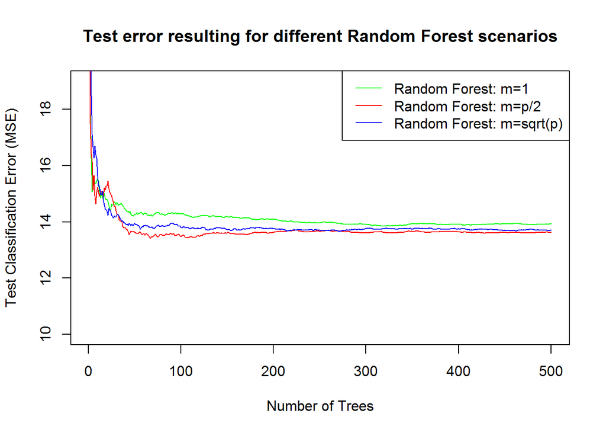

```r
#reload the original dataset to start from a clean position
data("Boston")
#Set the seed to 1 to ensure repea
set.seed(1)
#Split the Boston data into 50% training data and 50% test data
train = sample(1:nrow(Boston)[1], nrow(Boston)*0.5)
#the matrix of training predicators (all columns bar medv), i.e. 13=15-2
X.train = Boston[train,-13]
#The matrix of test predicators (all columns bar medv)
X.test = Boston[-train,-13]
#The response vector (mdev)
Y.train = Boston[train,13]
Y.test = Boston[-train,13]

#the number of variables randomly sampled as candidates at each split
p = dim(Boston)[2] - 1
p.2 = p*0.5
p.sq = sqrt(p)
#The number of tree to grow
max_tree = 500

#The random forest takes the following parameters and generates the mse:
# - the training data (x.train), the training response vector (y.train),
# - the test data (xtest), the test response (ytest)
# - the number of variables randonly sampled as candidates at each split (mtry)
# - the number of tree to grow, here we have three cases p, p.2 and p.sq as defined above (ntree)
rf.boston.p = randomForest(X.train, Y.train, xtest = X.test, ytest = Y.test, mtry = p, ntree = max_tree)
rf.boston.p.2 = randomForest(X.train, Y.train, xtest = X.test, ytest = Y.test, mtry = p.2, ntree = max_tree)
rf.boston.p.sq = randomForest(X.train, Y.train, xtest = X.test, ytest = Y.test, mtry = p.sq, ntree = max_tree)

#Plot the first graph where p=number of columns in the Boston data set -1
plot( 1:max_tree, # the number of tree to be displayed on the x-axis
      rf.boston.p$test$mse, #the calculated mse where mtry = p
      col = "green",
      type = "l",
      xlab = "Number of Trees",
      ylab = "Test Classification Error (MSE)",
      ylim = c(10, 19),
      main= "Test error resulting for different Random Forest scenarios")
#Graph the second line, were mtry = p.2
lines(1:max_tree, rf.boston.p.2$test$mse, col = "red", type = "l")
#Graph the third line, were mtry = p.sq
lines(1:max_tree, rf.boston.p.sq$test$mse, col = "blue", type = "l")
legend( "topright", c("Random Forest: m=1", "Random Forest: m=p/2", "Random Forest: m=sqrt(p)"),
        col = c("green", "red", "blue"), cex = 1, lty = 1)
```

Exercise 8: The aim is to predict Sales using regression trees and related approaches, treating the response as a quantitative variable.

In this exercise, it is assumed that the Sales, Price and CompPrice unit is $, as this is not specified explicitly in ‘?Carseats’.

1. Split the dataset into a training and a test set

```r
#Load the libraries
library(ISLR)
library(tree)
#reload the original dataset to start from a clean position
data("Carseats")
detach(Carseats)
#The database is searched by R when evaluating a variable,
#so objects in the database can be accessed by simply giving their names.
attach(Carseats)

#Vector containing 50% of the Carset dataset rows
train = sample(dim(Carseats)[1], dim(Carseats)[1]*0.5)
#Set the training set
Carseats.train = Carseats[train, ]
#Set the test set
Carseats.test = Carseats[-train, ]
```

2. Fit the regression tree to the training set. Plot the tree, and interpret the results. Calculate the test MSE.

The tree provides the following information:

The highest sales is $11,590 when the ShelveLoc is Good and the Price is strictly less than $123.5.

The MSE (i.e. the model prediction error) is 4.42%.

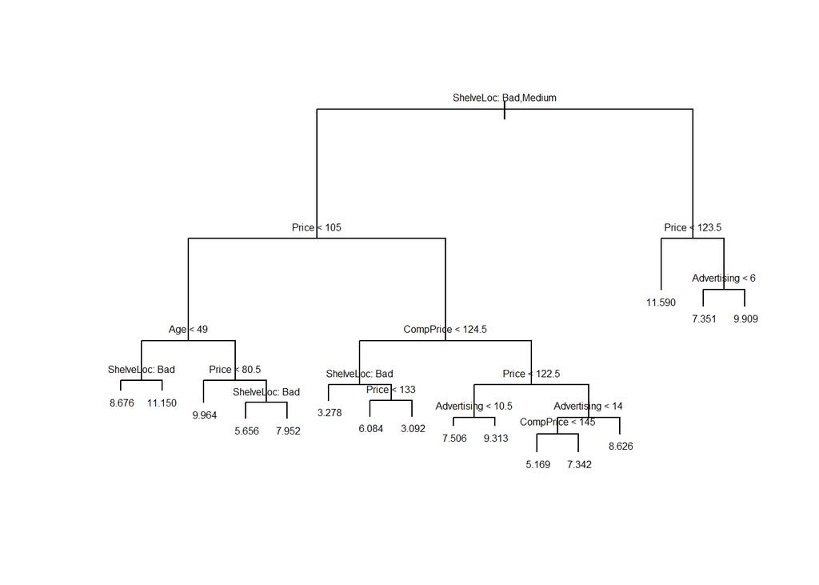

```r
#We set the seed of the random number generator to ensure the results are repeatable.
set.seed(1)
#The tree function() fits the predictor variables against the Sales predicted variable with the training dataset Carseats.train
tree.carseats = tree(Sales ~ ., data = Carseats.train)
#Plot the tree
plot(tree.carseats)
#Force the tree labels to show on the tree
text(tree.carseats, pretty = 0,cex = 0.5)
```

```r
#The predict function is used to evaluate the model performance on the test dataset.
#type="Class" is not set as we are not interested in returning class prediction.
pred.carseats = predict(tree.carseats, Carseats.test)
#Generate the Test MSE => MSE = mean((actual_y - predicted_y)^2), therefore:
mean((Carseats.test$Sales - pred.carseats)^2)
```

```
## [1] 4.427844
```

3. Use cross-validation to determine the optimal level of tree complexity. Does pruning the tree improve the test MSE.